# Predicting Rock Climbing Skill

Using Machine Learning to Analyze Strength Metrics in order to Predict an Individual’s Rock Climbing Ability.

Orion Marini

UCSB PSTAT 131 Winter 2024

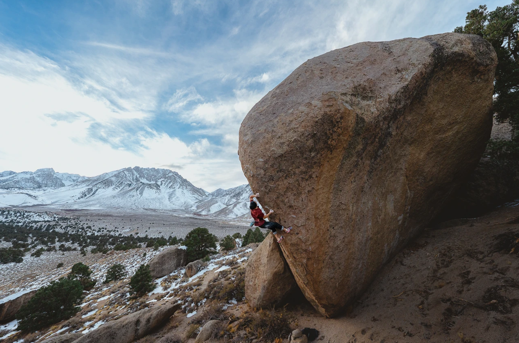

## Background

In the sport of rock climbing, the measurement of an individual’s skill level has always been somewhat of a contentious topic. Climbing skill can be fundamentally broken into two elements that contribute to performance: technique and strength. Technique is exceptionally hard to quantify, whereas strength can be measured in a multitude of ways. Therefore, it is indicative that strength will be interesting option to perform data analysis on in order to see how it contributes to an individual’s climbing ability. In order for us to quantify the connection between ability and strength, we can see how different strength metrics contribute to the differences between certain individual’s ability to climb routes graded with specific difficulty. In rock climbing, most routes are given a specific difficulty rating by the first ascentionist, the first person to climb the route, and based solely on their difficulty to complete without falling. Because this system relies heavily on the first ascentionist, it is inherently quite subjective. For this reason, we can focus on one particular difficulty scale that can help eliminate some of the potential bias. For boulder problems, shorter routes that are usually below 20ft tall and climbed sans rope, are graded with the V-scale which ranges sequentially from V0 being the easiest all the way to V17 being the hardest. Because boulder problems are so short, the V-scale is an excellent option for us to base our analysis off of due to their grade representing condensed difficulty rather than longer roped routes which may present other biases from the first ascentionist and other factors. So, if we were to measure climbing skill based off of this V-scale, we can devise a model that helps us take in metrics such as strength and determine their relationship with climbing grade difficulty. Ultimately, the goal of this assessment is to build a model that will allow individuals to predict their climbing difficulty grade based on their physical attributes, while also providing insight as to how improvement in specific areas may contribute to the greatest increase in overall skill.

# Data Information

For the construction of a model, we can use one of the multitude of public climbing surveys on the internet to gather the required data. Specifically, we will use a data sample taken from a 2017 survey across the internet forums of climbing (Reddit, Mountain Project, etc) orchestrated by the user u/higiff on the r/climbharder sub-Reddit. The original post containing the survey link can be found here: [(Visit Survey Page)](https://www.reddit.com/r/climbharder/comments/5qszhe/climbharder_training_survey/). Likewise, the results from the survey are collected in a Google Sheets page that can found here: [(Google Sheets Survey Results)](https://docs.google.com/spreadsheets/d/1J6d45EqIlIsIqNdi2X-Zl-EGFxf9d9T3R_W55xrpEAs/edit#gid=1650492946).

The survey results are formatted as a dataset that contains 630 total user submissions with 35 variables that we can analyze to formulate our model. In the dataset, there are both variables that are of extreme importance to our model as well as variables that don’t strictly contribute to our model building. Most importantly, our data includes three different response variables that we have the option to build our model on. The variables “Hardest V-Grade Ever Climbed”, “Hardest V-Grade Climbed in Last 3 Months”, and “Hardest V-Grade You Can Send 90% to 100% of the Time” all tell us something different about the individual’s climbing ability.

Firstly, the variable showing the hardest v-grade ever climbed tells us the single hardest boulder an individual has done. Initially, this seems like the most appropriate variable to build upon, as it demonstrates exactly what we are looking for in our proposed study question. However, it is important to realize that this variable may not be the best representation of climbing skill as, like stated before, boulders inherently display a bias towards different body sizes depending on the boulder. Likewise, the second variable given may pertain some bias as it is less likely that all individuals have climb boulders that accurately represent their overall climbing ability within the last three months. For these reasons, it would probably be a more accurate representation of overall skill if we model our findings on the third variable, “Hardest V-Grade You Can Send 90% to 100% of the Time” as exemplify an individual’s overall skill better than the other variables. Therefore, we will be using this variable as our response variable for our model fit. It is important to note that while the first two variables may not justify the extent of model building, the information that they provide may still be quite informative to some degree, but their inclusion/exclusion in our model should not influence it’s accuracy.

As for predictor variables, the data set in question has a decent number that we can potentially use in order to develop our model. “Frequency of Climbing Sessions Per Week”, “Hours Spent Training”, “Maximum Pull-ups”, and “General Strength Training Frequency” are just some of the variables that are good candidates to perform data analysis on. We will go into what these variables later as we develop our model and each of their significance become prevalent, as for now, information on all the variables can be found in the data set code book.

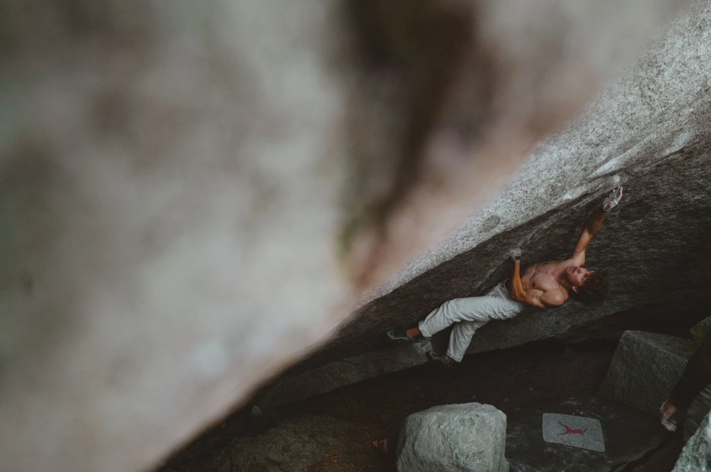

Yosemite Valley, California

## Exploratory Data Analysis

```r
# Loads the Climb Harder Dataset
data_frame <- read.csv("climbharder.csv")

# Removes Irrelevant Variables
data_frame <- data_frame %>%
  select(-Timestamp, -Hardest.Route.grade.climbed..Ewbank.grade., -Hardest.V.Grade.ever.climbed, -Hardest.V.Grade.climbed.in.the.Last.3.months, -Hardest.route.climbed.last.3.months..ewbank., -Route.grade.you.can.send.90.100..of.climbs, -Other.activities..ie.yoga..cardio.)
```

### Data Tidying

```r
# Renames Current Variables
climb_harder <- data_frame %>%
  rename(sex = Sex, height = Height..cm., weight = Weight..KG., arm_span = Arm.Span..cm., length_climbing = How.long.have.you.been.climbing.for., location = Where.do.you.climb., ability_grade = The.V.grade.you.can.send.90.100..of.routes, frequency_climbing = Frequency.of.climbing.sessions.per.week, avg_hours_climbing = Average.hours.climbing.per.week..not.including.training., avg_hours_training = Average.hours.Training.for.climbing.per.week, frequency_hangboarding = Hangboard.Frequency.per.week, hangboard_grips = Hangboard.grips.used, hangboard_style = Style.of.Hangboarding.chosen, max_weight_halfcrimp = Max.Weight.hangboard.18mm.edge...Half.crimp..KG....10.seconds...added.weight.only., max_weight_opencrimp = Max.Weight.hangboard.18mm.edge...open.crimp..KG...10.seconds....added.weight.only., min_edge_halfcrimp = Min.Edge.used..mm...kg.if.weight.added.....Half.Crimp..10.seconds., min_edge_opencrimp = Min.Edge.used..mm...kg.if.weight.added....Open.crimp..10.seconds.., frequency_campusboard = Campus.Board.frequency.per.week, avg_hours_campusboarding = Campus.Board.time.per.week..hours., frequency_endurance = Frequency.of.Endurance.training.sesions.per.week, type_endurance = Endurance.training, frequency_strength_training = General.Strength.Training.frequency.per.week, avg_hours_strenght_training = Time.spent.General.strength.training..hours., type_strength_training = Type.of.Strength.training, max_pullup = Max.pull.up.reps, max_weight_pullups = X5.rep.max.weighted.pull.ups, max_pushups = max.push.ups.reps, max_time_Lsit = max.L.sit.time)
```

To begin our data analysis, the first thing we must do is load our data set into R and tidy it. Because we already know that we do not need some variables from our data set, we can go ahead and remove them here alongside our import. The variables that we will not be including are the additional two V-grade variables, the other activities variable, three variables that describe an individual’s climbing grades of longer, roped climbs and the “timestamp” variable. These variables will intuitively have no impact on the data analysis we have proposed above, so it is safe to remove them from our data set for clarity sake. Additionally, we can go ahead and rename many of variables from the original data set to ones that will be more convenient to include in future computations. Most importantly, our main response variable is now designated with the name “ability_grade”. Like with the original data set, descriptions of each variable can befound within the climbing hard code book.

```r
climb_harder %>%
  head() %>%
  kbl() %>%
  kable_styling(font_size = 15) %>%
  scroll_box(width = "100%", height = "500px")
```

| sex | height | weight | arm_span | length_climbing | location | ability_grade | frequency_climbing | avg_hours_climbing | avg_hours_training | frequency_hangboarding | hangboard_grips | hangboard_style | max_weight_halfcrimp | max_weight_opencrimp | min_edge_halfcrimp | min_edge_opencrimp | frequency_campusboard | avg_hours_campusboarding | frequency_endurance | type_endurance | frequency_strength_training | avg_hours_strenght_training | type_strength_training | max_pullup | max_weight_pullups | max_pushups | max_time_Lsit |
| --- | --- | --- | --- | --- | --- | --- | --- | --- | --- | --- | --- | --- | --- | --- | --- | --- | --- | --- | --- | --- | --- | --- | --- | --- | --- | --- | --- |
| Male | 173 | 77 | 178 | 4.5 - 5 years | Indoor and outdoor climbing | V6 | 4 | 8 | 6 | 0 | I don’t Hangboard | I don’t hangboard | 0 | 0 | 0 | 0 | 0 | 0 | 1 | 4x4 | 3 | 4 | Antagonists, Legs, Core | 15 | 29 | 40 | 30 |
| Male | 180 | 81 | 180 | 3 - 3.5 years | Indoor Climbing only | V1 | 1 | 3 | 10 | 2 | Open Crimp, Front 3, Back 3, Middle 2, Slopers | Repeaters |  | 81kg |  |  | 0 | 0 | 1 | Laps of routes | 2 | 2 | Antagonists, Legs, Core, Upper body pulling, Upper body pushing | 11 | 5 | 24 | 15 |
| Male | 178 | 67 | 175 | .5 - 1 years | Indoor and outdoor climbing | V5 | 3 | 4 | 3 | 2 | Open Crimp | Other protocol | 25 | 25 |  |  | 0 | 0 | 2 | 4x4, ARC, route climbing intervals | 3 | 2 | Antagonists, Core, Upper body pulling, Upper body pushing | 17 | 20 |  |  |
| Male | 173 | 70 | 178 | 9 - 9.5 years | Indoor and outdoor climbing | V3 | 2 | 6 | 1 | 1 | Half Crimp | Max weight | 15 |  |  |  | 0 | 0 | 1 | Laps of routes, route climbing intervals | 0 | 0 | Antagonists, Legs, Core, No other strength training | 8 |  | 30 |  |
| Male | 184 | 84 | 197 | 6.5 - 7 years | Indoor and outdoor climbing | V7 | 6 | 10 | 2 | 4 | Open Crimp | Min Edge, Other protocol |  |  | 8 | 8 | 0 | 0 | 2 | 4x4, Max moves, threshold intervals | 2 | 1 | Core, Upper body pushing |  |  |  |  |
| Male | 176 | 67 | 170 | 5 - 5.5 years | Indoor and outdoor climbing | V7 | 0 | 0 | 0 | 0 | I don’t Hangboard | I don’t hangboard |  |  |  |  | 0 | 0 | 0 | I don’t train for endurance | 4 | 6 | Legs, Core, Upper body pulling, Upper body pushing | 9 |  | 15 | 20 |

```r
# Converts required variables to numeric type.

convert_numeric <- c("max_weight_halfcrimp", "max_weight_opencrimp", "min_edge_halfcrimp", "min_edge_opencrimp", "max_pullup", "max_weight_pullups", "max_pushups", "max_time_Lsit","height","weight","arm_span","frequency_climbing","avg_hours_climbing", "avg_hours_training", "frequency_hangboarding","frequency_campusboard", "avg_hours_campusboarding", "frequency_endurance","frequency_strength_training")

for (i in convert_numeric) {
  climb_harder[[i]] <- climb_harder[[i]] %>%
  suppressWarnings() %>%
  as.numeric()
}
```

The next step involved in tidying our data is to convert variables to their appropriate state. The code chunk above outlines the process of converting the variables that are designated for hangboarding metrics (max_weight_halfcrimp, max_weight_opencrimp, etc) to numeric variables. As this data set is taken from a public survey, many of the response contain values that are not in a similar syntax as the rest of the data. For example, a brief visual analysis of the data set shows that for variables such as max_pushups or max_pullups, many user’s included “I don’t know” instead of leaving the response blank. We can mitigate this issue by converting many of the variables from character types to be numeric and removing character values/replacing them with numeric. It is important to point out that this is not deleting potential numeric data, just removing inputs that would not be beneficial for our use case. In other words, this should have minimal impact on the total number of missing values that we will discuss briefly.

```r
# Removes the "I dont boulder" response from the three grade variables
climb_harder <- climb_harder[climb_harder$ability_grade != "I don't boulder",]


# Converts length_climbing, location, and ability_grade to factors.
levels_order_grade <- c("I don't boulder","V0", "V1", "V2", "V3", "V4", "V5", "V6", "V7", "V8", "V9", "V10", "V11")
levels_order_length <- c("0 - .5 years",".5 - 1 years", "1 - 1.5 years","1.5 - 2 years", "2 - 2.5 years", "2.5 - 3 years", "3 - 3.5 years", "3.5 - 4 years", "4 - 4.5 years", "4.5 - 5 years", "5 - 5.5 years", "5.5 - 6 years", "6 - 6.5 years", "6.5 - 7 years", "7 - 7.5 years", "7.5 - 8 years", "8 - 8.5 years", "8.5 - 9 years", "9 - 9.5 years", "9.5 - 10 years", "10 - 10.5 years", "10.5 - 11 years", "11 - 11.5 years", "11.5 - 12 years", "12 - 12.5 years", "12.5 - 13 years", "13 - 13.5 years", "13.5 - 14 years", "14 - 14.5 years", "14.5 - 15 years", "More than 15 years")
levels_order_location <- c("Indoor Climbing only","Indoor and outdoor climbing", "Outdoor Climbing only")
levels_order_sex <- c("Male", "Female")
climb_harder$ability_grade <- factor(climb_harder$ability_grade, levels = levels_order_grade)
climb_harder$length_climbing <- factor(climb_harder$length_climbing, levels = levels_order_length)
climb_harder$location <- factor(climb_harder$location, levels = levels_order_location)
climb_harder$sex <- factor(climb_harder$sex, levels = levels_order_sex)
```

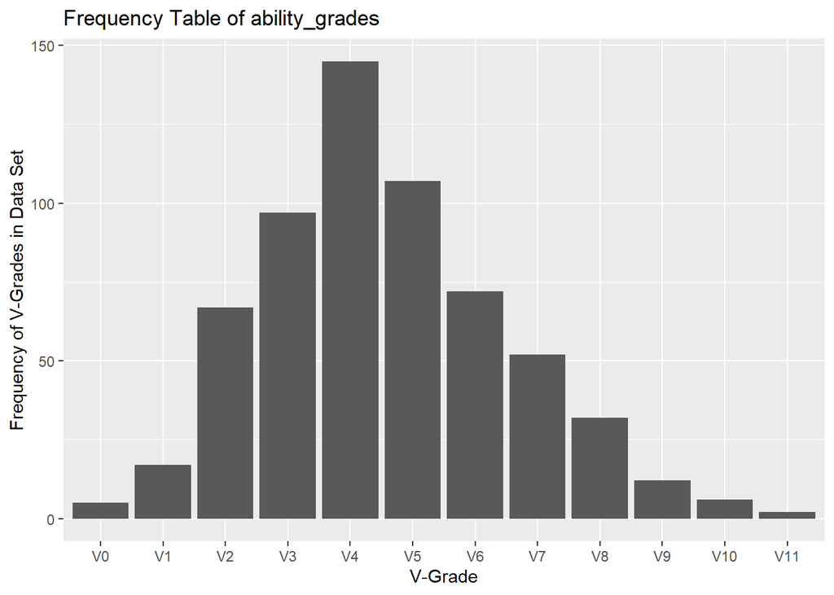

```r
ggplot(climb_harder, aes(x=ability_grade)) + geom_histogram(stat="Count") + labs(title = "Frequency Table of ability_grades", x = "V-Grade", y = "Frequency of V-Grades in Data Set")
```

In addition to converting variables to numeric, a few variables within our data set still need to be factorized in order to be fit our model. In the code above, sex, length_climbing, location, and ability_grade are all converted to factors. Additionally, we can remove any observations that contain the response “I don’t boulder” because there would be no point in processing data of individuals who would introduce bias into our models. With this step complete, we can produce a frequency histogram of our response variable ability_grade, or V-Grade sendable 90% to 100% of the time, as shown above.

```r
# Adds variable row_id to join new variables
climb_harder <- climb_harder %>%
  mutate(row_id = row_number())

# Adds binary variables for the hangboard_grips variable into a new data frame.
df_separated <- climb_harder %>%
  separate_rows(hangboard_grips, sep = ",\\s*") %>%
  mutate(value = 1)

df_hangboard_grips <- df_separated %>%
  pivot_wider(names_from = hangboard_grips, values_from = value, values_fill = list(value = 0), id_cols = row_id)

# Renames the new variables.

df_hangboard_grips <- df_hangboard_grips %>%
  rename(hangboard_grip.no_hangboard = "I don't Hangboard", hangboard_grip.full_crimp = "Full Crimp", hangboard_grip.half_crimp = "Half Crimp", hangboard_grip.open_crimp = "Open Crimp", hangboard_grip.front3 = "Front 3", hangboard_grip.back3 = "Back 3", hangboard_grip.front2 = "Front 2", hangboard_grip.middle2 = "Middle 2", hangboard_grip.back2 = "Back 2", hangboard_grip.slopers = "Slopers", hangboard_grip.pinch = "Pinch", hangboard_grip.monos = "Monos")

# Adds binary variables for the hangboard_style variable into a new data frame.
df_separated <- climb_harder %>%
  separate_rows(hangboard_style, sep = ",\\s*") %>%
  mutate(value = 1)

df_hangboard_style <- df_separated %>%
  pivot_wider(names_from = hangboard_style, values_from = value, values_fill = list(value = 0), id_cols = row_id)

# Renames the new variables.

df_hangboard_style <- df_hangboard_style %>%
  rename(hangboard_style.no_hangboard = "I don't hangboard", hangboard_style.min_edge = "Min Edge", hangboard_style.repeaters = "Repeaters", hangboard_style.one_arm = "One arm hang program", hangboard_style.no_hangs = "\"no hangs\"", hangboard_style.other = "Other protocol")

# Adds binary variables for the type_endurance variable into a new data frame.
climb_harder <- climb_harder %>%
  mutate(type_endurance = ifelse(type_endurance == "" | is.na(type_endurance), "I don't train for endurance", type_endurance))

df_separated <- climb_harder %>%
  separate_rows(type_endurance, sep = ",\\s*") %>%
  mutate(value = 1)

df_type_endurance <- df_separated %>%
  pivot_wider(names_from = type_endurance, values_from = value, values_fill = list(value = 0), id_cols = row_id)

# Renames the new variables.

df_type_endurance <- df_type_endurance %>%
  rename(type_endurance.no_train = "I don't train for endurance", type_endurance.4x4 = "4x4", type_endurance.repeater = "hangboard repeater protocols", type_endurance.max_moves = "Max moves", type_endurance.systems_board = "systems boards", type_endurance.laps = "Laps of routes", type_endurance.arc = "ARC", type_endurance.campus = "Feet on 'campusing'", type_endurance.route_intervals = "route climbing intervals", type_endurance.threshold_intervals = "threshold intervals", type_endurance.other = "other")


# Adds binary variables for the type_endurance variable into a new data frame.
df_separated <- climb_harder %>%
  separate_rows(type_strength_training, sep = ",\\s*") %>%
  mutate(value = 1)

df_type_strength_training <- df_separated %>%
  pivot_wider(names_from = type_strength_training, values_from = value, values_fill = list(value = 0), id_cols = row_id)

# Renames the new variables.

df_type_strength_training <- df_type_strength_training %>%
  rename(type_strength_training.none = "No other strength training", type_strength_training.antagonists = "Antagonists", type_strength_training.legs = "Legs", type_strength_training.core = "Core", type_strength_training.upperbody_pulling = "Upper body pulling", type_strength_training.upperbodypushing = "Upper body pushing")

# Merges the newly created data frames containing the binary variables for hangboard_grips, hangboard_style, type_endurance, and type_strength training into the climb_harder data frame.

climb_harder_binary <- climb_harder
climb_harder_binary_isolated <- df_hangboard_grips
climb_harder_binary_isolated <- merge(climb_harder_binary_isolated,df_hangboard_style, by="row_id")
climb_harder_binary_isolated <- merge(climb_harder_binary_isolated,df_type_endurance, by="row_id")
climb_harder_binary_isolated <- merge(climb_harder_binary_isolated,df_type_strength_training, by="row_id")

# Now climb_harder_binary can be used as the original dataset + the binary variables, climb_harder is the dataset without the binary variables, and climb_harder_binary_isolated is the data frame containing just the isolate binary variables
climb_harder_binary <- merge(climb_harder_binary,climb_harder_binary_isolated, by = "row_id")
climb_harder_binary <- select(climb_harder_binary, -row_id)
climb_harder_binary_isolated <- select(climb_harder_binary_isolated, -row_id)
climb_harder <- select(climb_harder, -row_id)
```

The last step of data tidying involves splitting one variable into a bunch of new, binary variables for certain predictor variables in our data set. In the case of the survey there are four questions that allow for the submitter to select any of the options listed from the question. For example, when asked what style of hangboard training an individual utilizes, they could select any combination from “max weight”, “min edge”, “repeaters”, “one arm program”, “no hangs”, “other protocol”, or “i don’t hangboard”. This leaves us with a problem of implementing into our future model because the variable hangboard_style would include values such as “max weight, min edge, repeaters”, and there would not be an efficient way to see how the use of either one of these predictors individually effects our model. In order to compensate for this, we can create a new binary variable for each of the answer selections for each variable that represents a question. If a user selects “max weight” and “other protocol”, then these new binary variables get assigned the value 1, and they are assigned 0 for the options that are not selected. One caveat from this procedure is the creation of a multitude of new variables for these four questions, but it compensates for this by making fitting a lot simpler and allows us to see how each of these answers can individually effect climbing grade and to what degree. In tidying, there were four total variables that needed to have binary variables created: hangboard_grips, hangboard_style, type_endurance, and type_strength_training, the code for which is outlined in the above chunk. For computation sake, we will treat the climb_harder data frame and the data frame containing these binary variables, climb_harder_binary, as two separate entities for the time being, and only implement them when we need to.

As a final step of tidying, lets take a look at the first few elements of both the climb_harder and climb_harder binary data frames by using the head() function in R.

```r
climb_harder %>%
  head() %>%
  kbl() %>%
  kable_styling(font_size = 15) %>%
  scroll_box(width = "100%", height = "250px")
```

| sex | height | weight | arm_span | length_climbing | location | ability_grade | frequency_climbing | avg_hours_climbing | avg_hours_training | frequency_hangboarding | hangboard_grips | hangboard_style | max_weight_halfcrimp | max_weight_opencrimp | min_edge_halfcrimp | min_edge_opencrimp | frequency_campusboard | avg_hours_campusboarding | frequency_endurance | type_endurance | frequency_strength_training | avg_hours_strenght_training | type_strength_training | max_pullup | max_weight_pullups | max_pushups | max_time_Lsit |
| --- | --- | --- | --- | --- | --- | --- | --- | --- | --- | --- | --- | --- | --- | --- | --- | --- | --- | --- | --- | --- | --- | --- | --- | --- | --- | --- | --- |
| Male | 173 | 77 | 178 | 4.5 - 5 years | Indoor and outdoor climbing | V6 | 4 | 8 | 6 | 0 | I don’t Hangboard | I don’t hangboard | 0 | 0 | 0 | 0 | 0 | 0 | 1 | 4x4 | 3 | 4 | Antagonists, Legs, Core | 15 | 29 | 40 | 30 |
| Male | 180 | 81 | 180 | 3 - 3.5 years | Indoor Climbing only | V1 | 1 | 3 | 10 | 2 | Open Crimp, Front 3, Back 3, Middle 2, Slopers | Repeaters | NA | NA | NA | NA | 0 | 0 | 1 | Laps of routes | 2 | 2 | Antagonists, Legs, Core, Upper body pulling, Upper body pushing | 11 | 5 | 24 | 15 |
| Male | 178 | 67 | 175 | .5 - 1 years | Indoor and outdoor climbing | V5 | 3 | 4 | 3 | 2 | Open Crimp | Other protocol | 25 | 25 | NA | NA | 0 | 0 | 2 | 4x4, ARC, route climbing intervals | 3 | 2 | Antagonists, Core, Upper body pulling, Upper body pushing | 17 | 20 | NA | NA |
| Male | 173 | 70 | 178 | 9 - 9.5 years | Indoor and outdoor climbing | V3 | 2 | 6 | 1 | 1 | Half Crimp | Max weight | 15 | NA | NA | NA | 0 | 0 | 1 | Laps of routes, route climbing intervals | 0 | 0 | Antagonists, Legs, Core, No other strength training | 8 | NA | 30 | NA |
| Male | 184 | 84 | 197 | 6.5 - 7 years | Indoor and outdoor climbing | V7 | 6 | 10 | 2 | 4 | Open Crimp | Min Edge, Other protocol | NA | NA | 8 | 8 | 0 | 0 | 2 | 4x4, Max moves, threshold intervals | 2 | 1 | Core, Upper body pushing | NA | NA | NA | NA |
| Male | 176 | 67 | 170 | 5 - 5.5 years | Indoor and outdoor climbing | V7 | 0 | 0 | 0 | 0 | I don’t Hangboard | I don’t hangboard | NA | NA | NA | NA | 0 | 0 | 0 | I don’t train for endurance | 4 | 6 | Legs, Core, Upper body pulling, Upper body pushing | 9 | NA | 15 | 20 |

```r
climb_harder_binary %>%
  head() %>%
  kbl() %>%
  kable_styling(font_size = 15) %>%
  scroll_box(width = "100%", height = "250px")
```

| sex | height | weight | arm_span | length_climbing | location | ability_grade | frequency_climbing | avg_hours_climbing | avg_hours_training | frequency_hangboarding | hangboard_grips | hangboard_style | max_weight_halfcrimp | max_weight_opencrimp | min_edge_halfcrimp | min_edge_opencrimp | frequency_campusboard | avg_hours_campusboarding | frequency_endurance | type_endurance | frequency_strength_training | avg_hours_strenght_training | type_strength_training | max_pullup | max_weight_pullups | max_pushups | max_time_Lsit | hangboard_grip.no_hangboard | hangboard_grip.open_crimp | … |
| --- | --- | --- | --- | --- | --- | --- | --- | --- | --- | --- | --- | --- | --- | --- | --- | --- | --- | --- | --- | --- | --- | --- | --- | --- | --- | --- | --- | --- | --- | --- |
| Male | 173 | 77 | 178 | 4.5 - 5 years | Indoor and outdoor climbing | V6 | 4 | 8 | 6 | 0 | I don’t Hangboard | I don’t hangboard | 0 | 0 | 0 | 0 | 0 | 0 | 1 | 4x4 | 3 | 4 | Antagonists, Legs, Core | 15 | 29 | 40 | 30 | 1 | 0 | … |
| Male | 180 | 81 | 180 | 3 - 3.5 years | Indoor Climbing only | V1 | 1 | 3 | 10 | 2 | Open Crimp, Front 3, Back 3, Middle 2, Slopers | Repeaters | NA | NA | NA | NA | 0 | 0 | 1 | Laps of routes | 2 | 2 | Antagonists, Legs, Core, Upper body pulling, Upper body pushing | 11 | 5 | 24 | 15 | 0 | 1 | … |
| Male | 178 | 67 | 175 | .5 - 1 years | Indoor and outdoor climbing | V5 | 3 | 4 | 3 | 2 | Open Crimp | Other protocol | 25 | 25 | NA | NA | 0 | 0 | 2 | 4x4, ARC, route climbing intervals | 3 | 2 | Antagonists, Core, Upper body pulling, Upper body pushing | 17 | 20 | NA | NA | 0 | 1 | … |
| Male | 173 | 70 | 178 | 9 - 9.5 years | Indoor and outdoor climbing | V3 | 2 | 6 | 1 | 1 | Half Crimp | Max weight | 15 | NA | NA | NA | 0 | 0 | 1 | Laps of routes, route climbing intervals | 0 | 0 | Antagonists, Legs, Core, No other strength training | 8 | NA | 30 | NA | 0 | 0 | … |
| Male | 184 | 84 | 197 | 6.5 - 7 years | Indoor and outdoor climbing | V7 | 6 | 10 | 2 | 4 | Open Crimp | Min Edge, Other protocol | NA | NA | 8 | 8 | 0 | 0 | 2 | 4x4, Max moves, threshold intervals | 2 | 1 | Core, Upper body pushing | NA | NA | NA | NA | 0 | 1 | … |
| Male | 176 | 67 | 170 | 5 - 5.5 years | Indoor and outdoor climbing | V7 | 0 | 0 | 0 | 0 | I don’t Hangboard | I don’t hangboard | NA | NA | NA | NA | 0 | 0 | 0 | I don’t train for endurance | 4 | 6 | Legs, Core, Upper body pulling, Upper body pushing | 9 | NA | 15 | 20 | 1 | 0 | … |

### Missing Data

As briefly touched on before, there seems to be a conflict with missing data inside the data set. This makes complete sense as the data comes from a public online survey where users had the option to not answer all the questions in their entirety. Because the data set consists of around 630 observations at the beginning, it is important that we do not carelessly remove data that has missing values as we have a limited number of total observations. For this reason, we will take some time to look into the trends behind the missing data and see if there is anything we can do to either mitigate the missing data’s influence or simply not use those variables in our model. The first step is to produce a missing variables graph to determine if any missingness trends exist. It is important to note that we do not have to look at the climb_harder_binary dataset due to the fact that all of the variables introduced in that data set are destined to be either 1 or 0, so we can look at the climb_harder data set to save us some time from looking at extra variables.

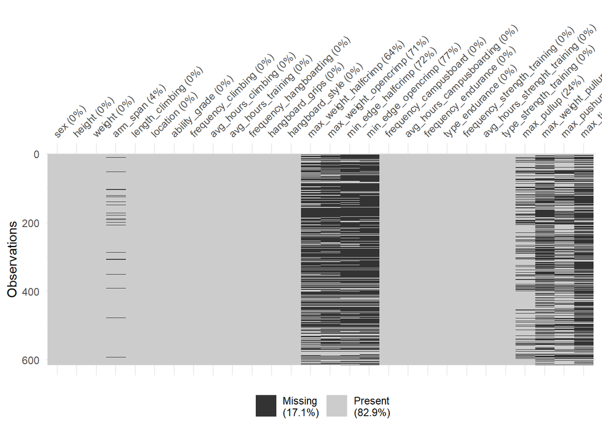

```r
vis_miss(climb_harder)
```

As the graph above shows, a large majority of the values from variables about hang boarding routines and normal exercise routes are missing. There is a chance that the inclusion of these variables in our model fit may introduce dramatic inaccuracies, so we will have to be very selective if we want to include them or not. Other than those variables, there does not seem to be a large amount of data from the rest of the survey that does not have respective values except for a few instances for values of arm_span.

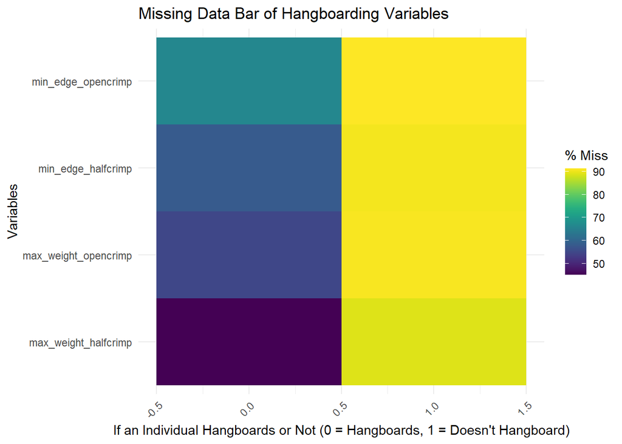

```r
# Creates vector with hangboarding variables that contain missing data.
major_missing<-c("max_weight_halfcrimp", "max_weight_opencrimp", "min_edge_halfcrimp", "min_edge_opencrimp","hangboard_grip.no_hangboard")

# Creates a new temporary data frame that has only the variables from the vector above.
climb_harder_missing_test <- select(climb_harder_binary, major_missing)

# Creates a visual representation of hang boarding missing values versus people who hangboard and those who don't.
gg_miss_fct(x = climb_harder_missing_test, fct = hangboard_grip.no_hangboard) + labs(title = "Missing Data Bar of Hangboarding Variables", x = "If an Individual Hangboards or Not (0 = Hangboards, 1 = Doesn't Hangboard)", y = "Variables")
```

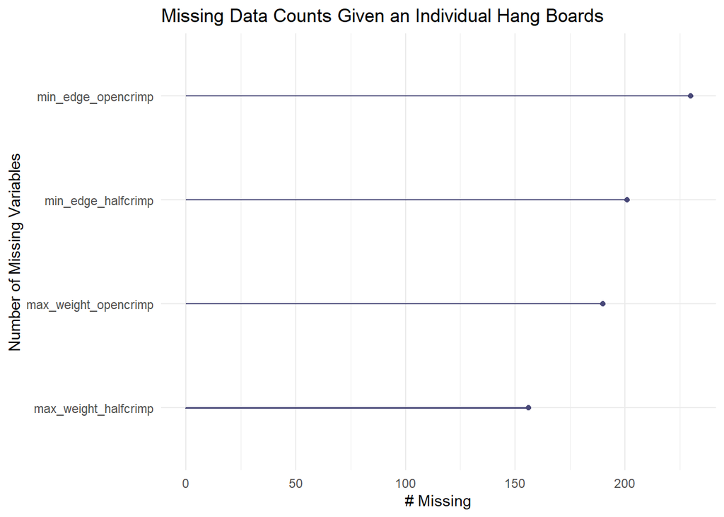

```r
# Creates a visual representation of hang boarding missing values given that an individual hangboards.
climb_harder_missing_test <- climb_harder_missing_test[climb_harder_missing_test$hangboard_grip.no_hangboard != 1,]
climb_harder_missing_test <- select(climb_harder_missing_test, -hangboard_grip.no_hangboard)
gg_miss_var(climb_harder_missing_test) + labs(title = "Missing Data Counts Given an Individual Hang Boards", x = "Number of Missing Variables")
```

Looking at the first of the two figures above, an obvious trend begins to emerge that shows that there is less missing values for individuals who hang board versus those who do not, which makes intuitive sense. Comparatively, nearly all the people who say they don’t hang board have missing data. Where as the other variables range from somewhere under 50% to just around 70% missing data. Looking at the second figure which focus’ on only the proportion of data that is missing from people who hang board tells us the number of entries missing from the data set. This tells us that there probably is not enough data within our data set in order to use these variables as predictors for our response. With this in mind, the accuracy of our model will be significantly higher if we do not include the predictor variables with large amounts of missing data.

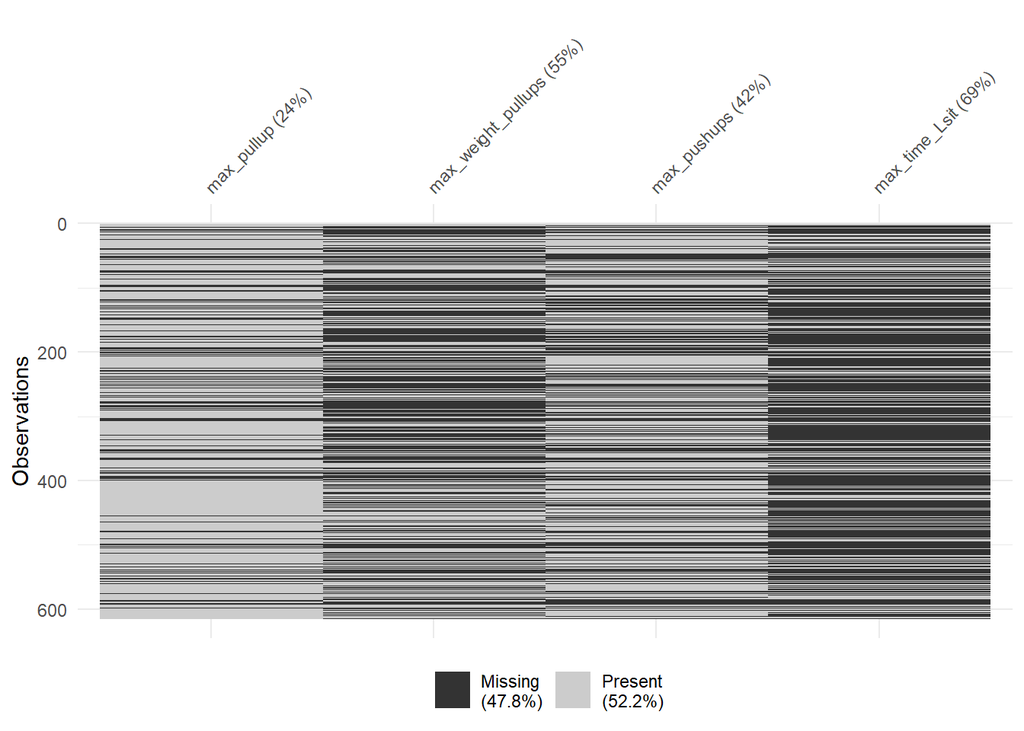

```r
vis_miss(climb_harder[25:28])
```

Lastly, it may be useful to take a closer look at the last few variables from our data set that describe physical, non climbing workouts. The graph above demonstrates that there is indeed a high proportion of missing data, but there it is question whether two variables out of the four, max_pullup and max_pushups, can be included. For now, we will exclude the other two variables while keeping those in because they have a lower missing rate. In the future, we will determine if we need to remove these as well when fitting a model.

In summary, we can remove max_weight_pullups, max_time_Lsit, max_weight_halfcrimp, max_weight_opencrimp, min_edge_halfcrimp, and min_edge_opencrimp and look at our new data frame missing value graph.

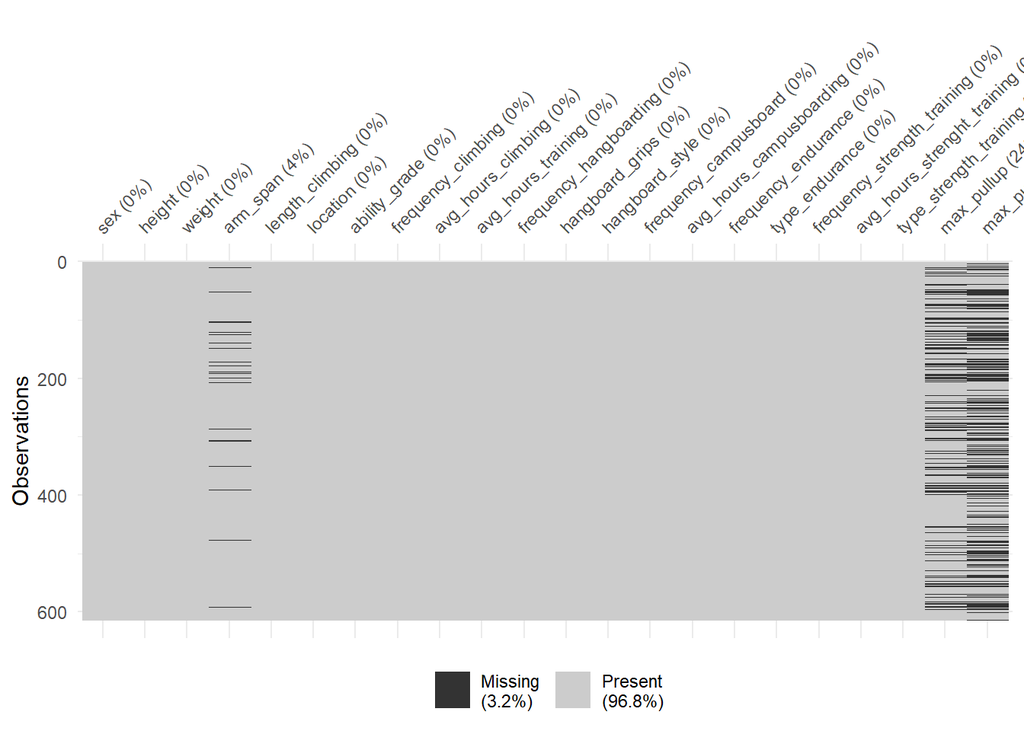

```r
vis_miss(climb_harder)
```

# Description of Predictors

Now that the data is tidy’d and missing values has been addressed, we can begin to describe our remaining predictors and how they may impact the response variable.

- `sex` Is a factor representing an individual’s sex, Male or Female
- `height` A numeric variable representing an individual’s height measured in cm.
- `weight` A numeric variable representing an individual’s weight measured in kg.
- `arm_span` A numeric variable representing the length from finger tip to tip, measured in cm.
- `length_climbing` A factor representing the years an individual has been climbing, in steps of 0.5 years, from 0 to 15.
- `location` A factor depicting where an individual climbs: Indoor, Outdoor, or both.
- `frequency_climbing` The average number of times climbing per week, from zero to seven.
- `avg_hours_climbing` The average number of hours spent climbing in a given week.
- `avg_hours_training` The average number of hours spent training in a given week.
- `frequency_hangboarding` The average number of times hang boarding per week, from zero to seven.
- `hangboard_grips` Different types of hang boarding training techniques used, split into multiple variables in the climb_harder_binary data frame. Options include: Full Crimp, Half Crimp, Open Crimp, Front 3, Back 3, Front 2, Middle 2, Back 2, Slopers, Pinch, Monos, I don’t hangboard.
- `hangboard_style` The style of hang board training used, split into multiple variables in the climb_harder_binary data frame. Options include: Max weight, Min Edge, Repeaters, One arm hang program, no hangs, other protocol, and I don’t hangboard.
- `frequency_campusboard` The average number of times campus boarding per week, from zero to seven.
- `avg_hours_campusboarding` The average number of hours spent campus boarding in a given week.
- `frequency_endurance` The average number of times spent training endurance per week, from zero to seven.
- `type_endurance` The type of endurance training used, split into multiple variables in the climb_harder_binary data frame. Options include: I dont train endurance, 4x4, hangboard repeater protocols, max moves, systems boards, laps of routes, ARC, feet on campusing, route climbing intervals, threshold intervals, and other.
- `frequency_strenght_training` The average number of times spent training strength per week, from zero to seven.
- `avg_hours_strength_training` The average number of hours spent strength training in a given week.
- `type_strength_training` The type of strength training technique used, split into multiple variables in the climb_harder_binary data frame. Options include: Antagonists, Legs, Core, Upper body pulling, Upper body pushing, and No other strength training.
- `max_pullup` Maximum reps of pull-ups
- `max_pushups` Maximum reps of push-ups.

## Visual Trend Inspection

The next step in the data analysis process is defining basic trends within the data. To do this, we can formulate a number of graphs that will inform us of trends and correlations within our data. First, lets take a look into how height, weight, and arm span are distributed alongside climbing difficulty grade. This will give us a good idea as to the relative frequency of different climbing grades of those who responded to the survey compared to their basic physical attributes.

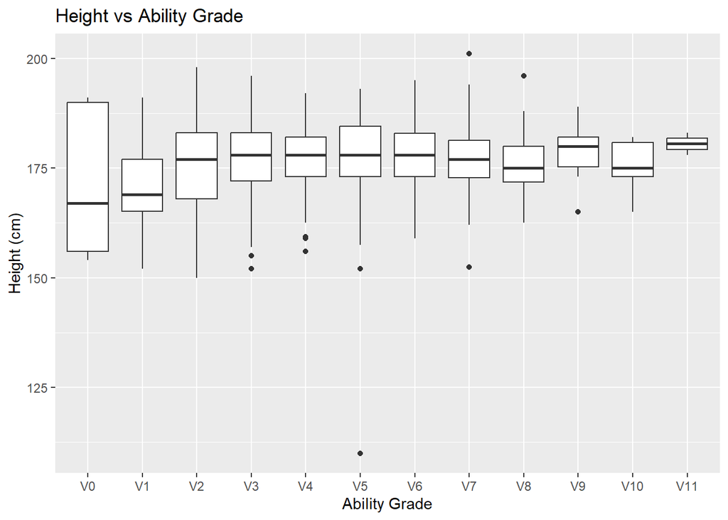

```r
ggplot(climb_harder, aes(x = ability_grade, y = height)) +
  geom_boxplot() +  labs(title = "Height vs Ability Grade", x = "Ability Grade", y = "Height (cm)")
```

The box plot above demonstrates quite an interesting trend within the data set between these two variables. The left side of the graph shows the widest box and nearly the widest whiskers, and the box and whisker sizes shrink as we move from left to right. In essence, this means that in the lower range of climbing grades, the quantile ranges for height are much wider than they are in the higher grade values. Notably, the a plot of the mean of height for each level of ability seems to have a varying slope.

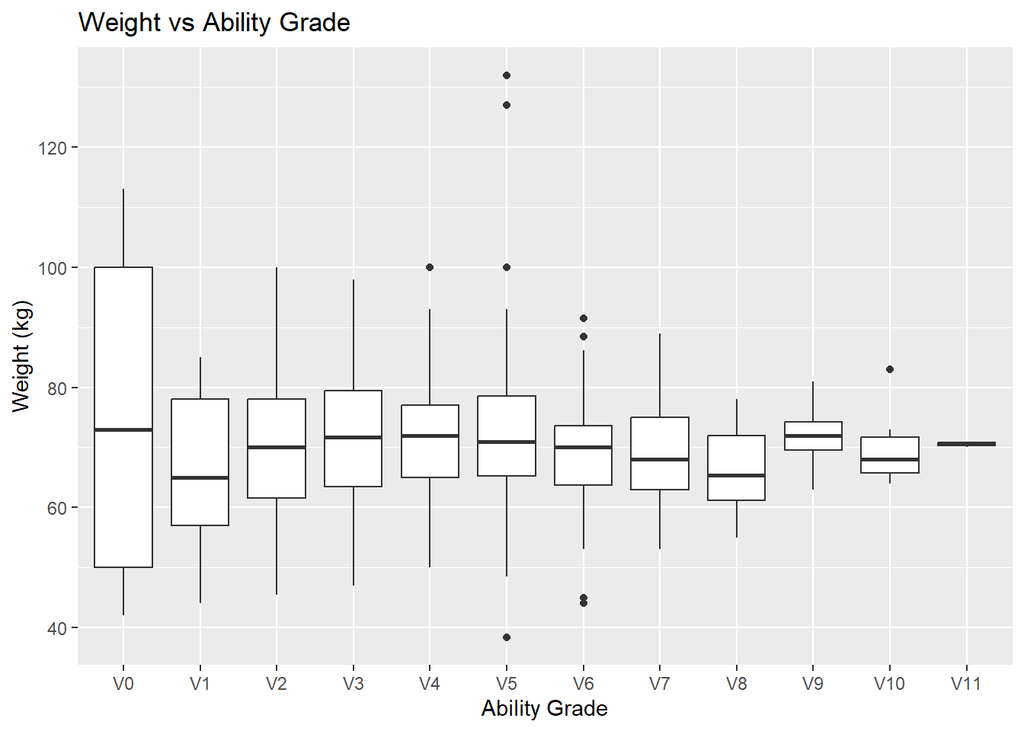

```r
ggplot(climb_harder, aes(x = ability_grade, y = weight)) +
  geom_boxplot() +  labs(title = "Weight vs Ability Grade", x = "Ability Grade", y = "Weight (kg)")
```

As before, a similar trend exists alongside the box and whisker plot of ability grade versus weight, where the weight values have more spread in the lower grade ranges and lower spread in the higher grade ranges.

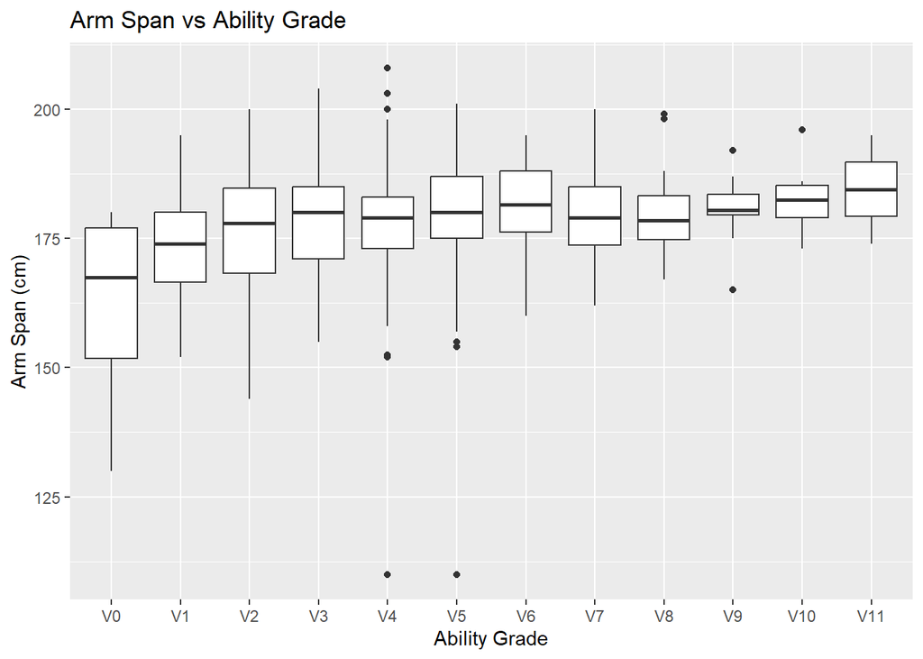

```r
ggplot(climb_harder, aes(x = ability_grade, y = arm_span)) +
  geom_boxplot() + labs(title = "Arm Span vs Ability Grade", x = "Ability Grade", y = "Arm Span (cm)")
```

Lastly, the box plot of arm span and ability grade shows a slightly different trend than the other two graphs. While the lower grade ranges does seem to have more spread than the higher ranges, this trend is less noticeable here than in the other two plots. One thing of importance to be noted here, however, is the fact that the mean seem to increase as climbing grade increases. This is exceptional information that we can use to start inputting into training model. It seems that the relationship between mean arm span and climbing ability is a lot stronger than that of weight or height, which seems to be relatively non-existent. In essence, arm_span may be a somewhat decent predictor of climbing grade, which intuitively makes sense as people with longer arm spans are more likely to be able to reach between holds.

Next, we can look at some of the relationships between climbing ability grade and other factors within the data set to see if any obvious trends are visible.

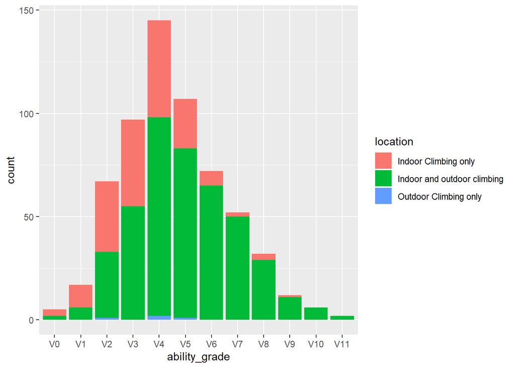

```r
ggplot(climb_harder, aes(fill=location, x=ability_grade)) +
    geom_bar()
```

The bar plot above shows us the distribution of the different levels of the location variable. As apparent, the lower grade ranges are represented by mostly indoor climbing, while the level of both indoor and outdoor climbing dominate the data set. This tells us that the variable may not be the most helpful when building our model, but if the predictor level value is indoor only, then they are more likely to be on the lower end of the grade spectrum.

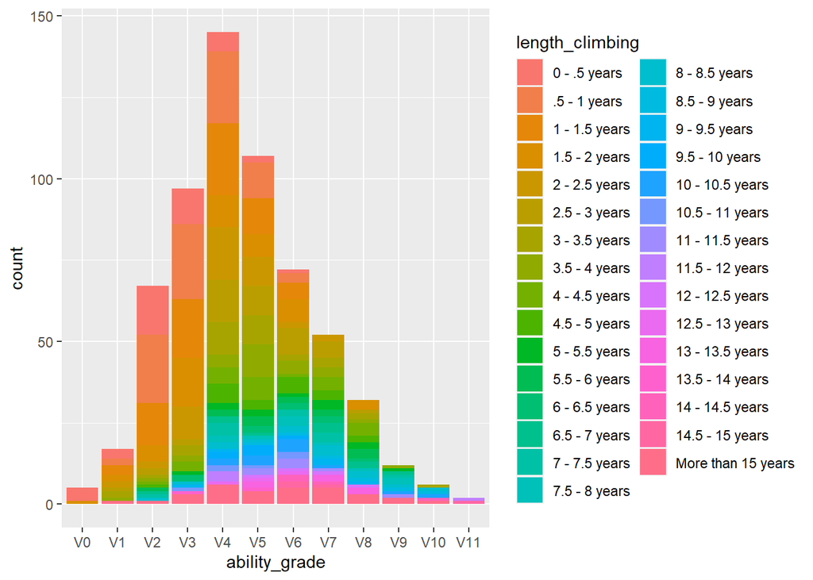

```r
ggplot(climb_harder, aes(fill=length_climbing, x=ability_grade)) +
    geom_bar()
```

On the other hand, the bar plot of variable for time spent climbing and ability grade seems to demonstrate a present relationship in the data. Like intuition suggests, those who have been climbing for longer times across their life are more likely to have a higher ability. Interestingly, It seems that a bulk of the data where the length_climbing value is between 0.5 and 3 years seems to sit between the grades of V1 and V6, whereas the majority of the data for older climbers is between V3 and V10. The trends outlined by this suggest to us that length_climbing may be a decent predictor to fit out model with.

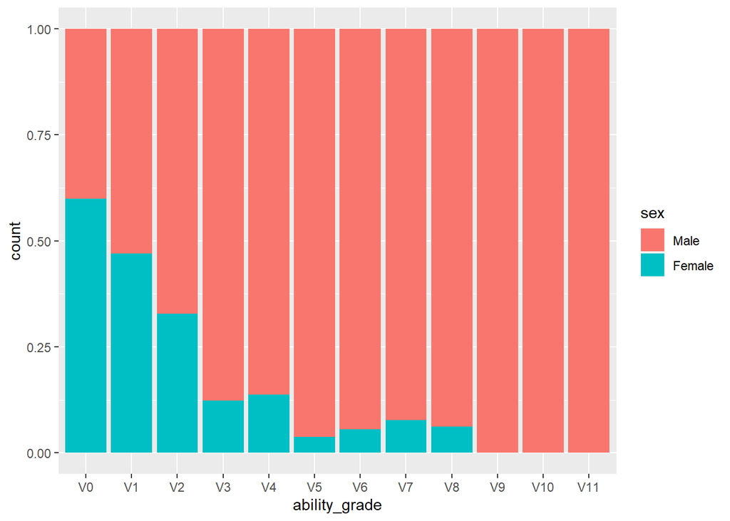

```r
ggplot(climb_harder, aes(fill=sex, x=ability_grade)) +
    geom_bar(position="fill")
```

Lastly, the plot of sex versus climbing grade shows that lower females, which represent a drastically lower proportion of the data set, are more likely to climb in the lower ranges than the higher ones. This is most likely due to the fact that less women over all answered the survey, rather than that men are naturally better at climbing. Nevertheless, this variable may still be a helpful predictor when building our model.

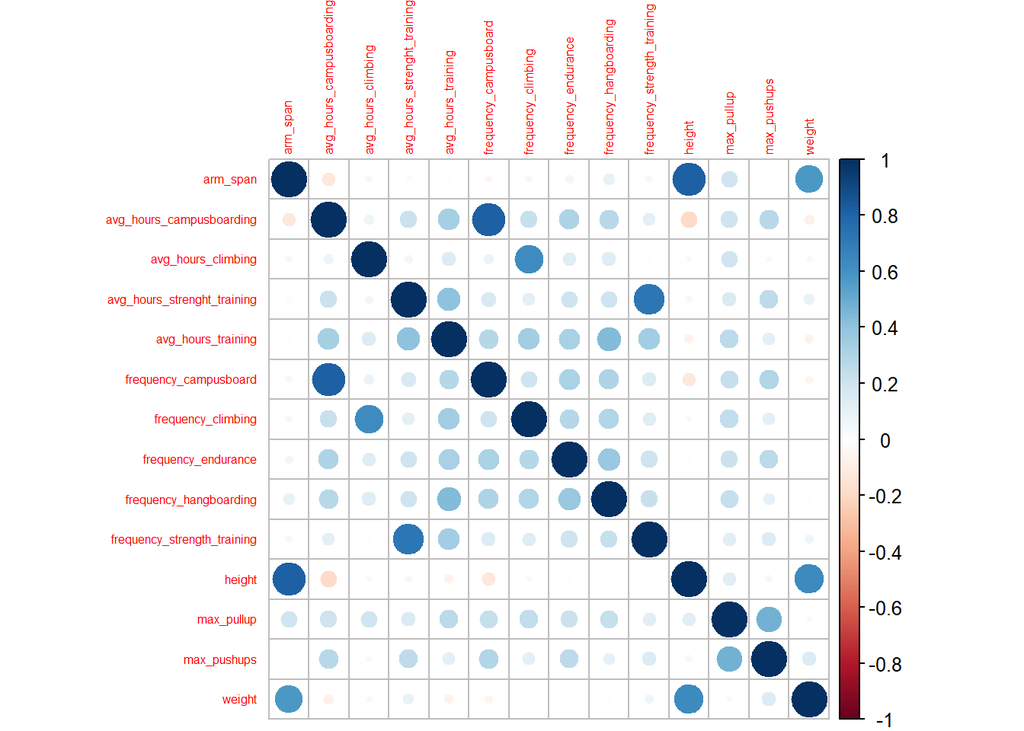

```r
climb_harder %>%
  select(where(is.numeric)) %>%
  cor(use = "pairwise.complete.obs") %>%
  corrplot(method = 'circle', order = "alphabet", tl.cex = 0.5)
```

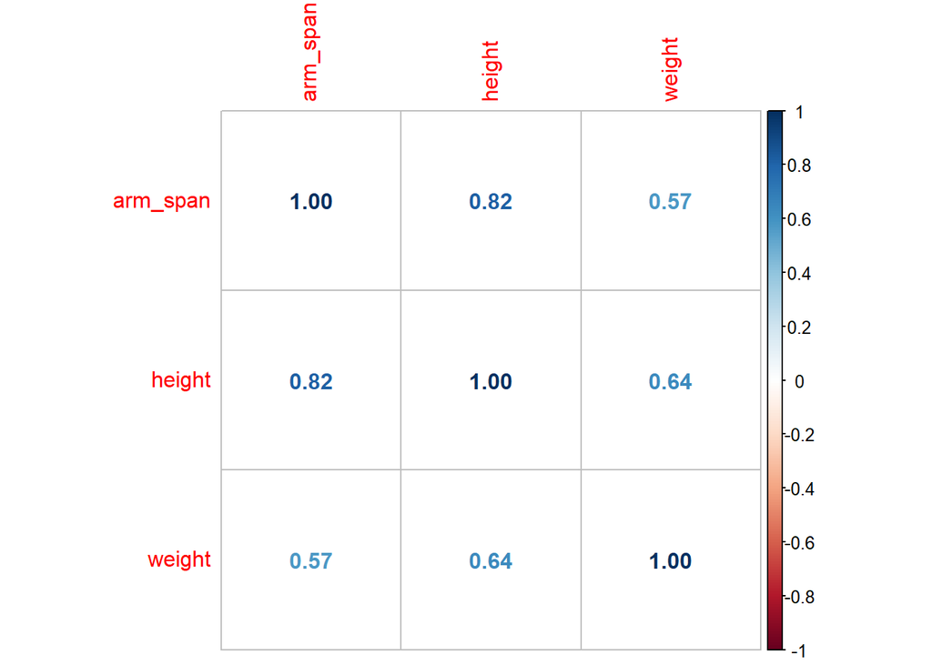

```r
climb_harder_test <- select(climb_harder, c("arm_span","height","weight"))
climb_harder_test %>%
  cor(use="pairwise.complete.obs") %>%
  corrplot(method = "number")
```

Each of the figures above describe some unique trends within the data set that have appeared so far. The first figure above is a general correlation plot of our data set for the numeric predictors. Some of the obviously connected variables do present positive correlations with each other, such as arm-span increasing with height and weight, which is highlighted by the second figure. While many other variables in the main correlation plot show less correlation between one another, there still seems to be an overall slight positive trend that may display some significance for us down the road. Critically, the existence of a positive correlation between a great deal of the variables included in the plot makes intuitive sense as a majority of them involve whether an individual is training. In essence, it makes sense that if an individual spends more time training, they will probably be more likely to spend time training different facets in order to improve.

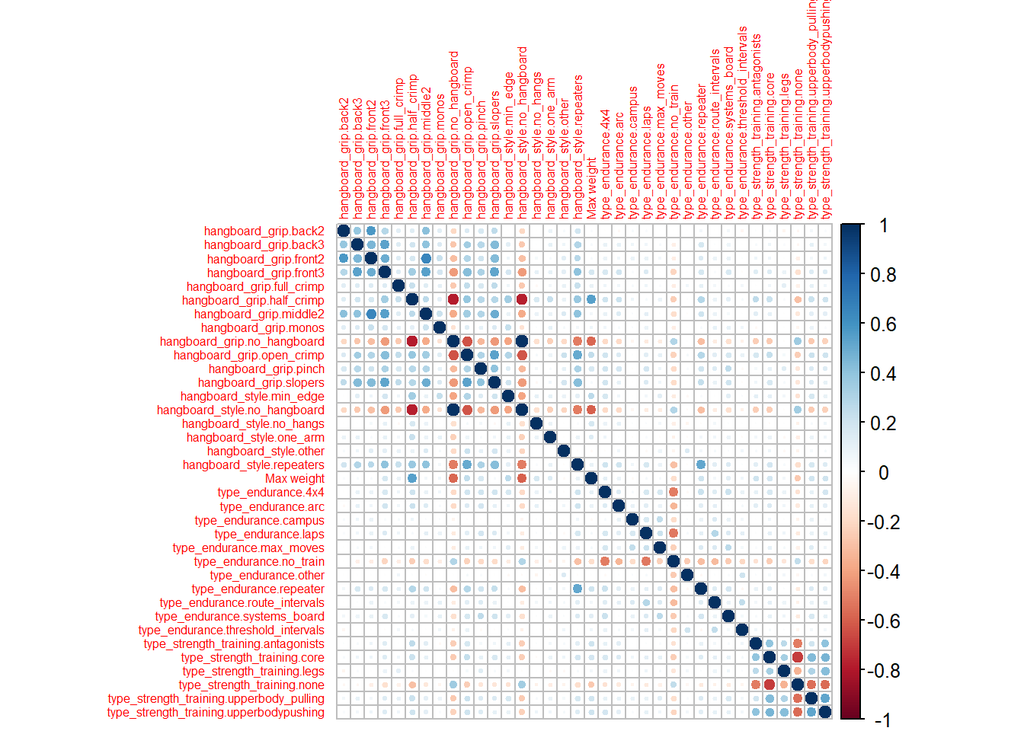

```r
climb_harder_binary_isolated %>%
  cor() %>%
  corrplot( order = "alphabet", tl.cex = 0.5)
```

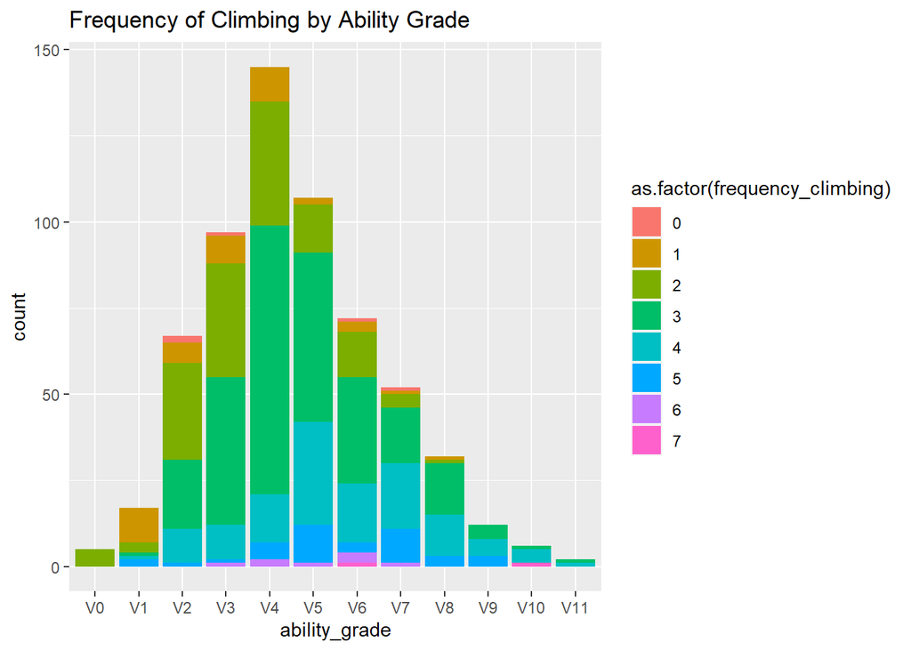

```r
ggplot(climb_harder, aes(fill=as.factor(frequency_climbing), x=ability_grade)) +
  geom_bar() +  labs(title = "Frequency of Climbing by Ability Grade")
```

Lastly for our visual inspection, we will look at the graph that with any prior knowledge of the subject, should be the greatest predictor of climb ability. The graph of frequency climbing per week against ability grade shows us that the correlation is not as strong as prior knowledge may dictate. The each level of the factor seems to have a pretty distinct bell curve, but the difference between the means of each level is not as substantial as anticipated. Nevertheless, the mean difference should help add confidence to the recipe for our model.

To summarize, a brief visual inspection of the trends such as these in our data set tell us that there does seem to be some correlation between the predictors in the data set and the outcome variable, ability grade. Ultimately, to be confident in the relationship between these variables and develop a good way to predict what an individual’s climbing ability is based on their values for each predictor, we must develop a statistical model.

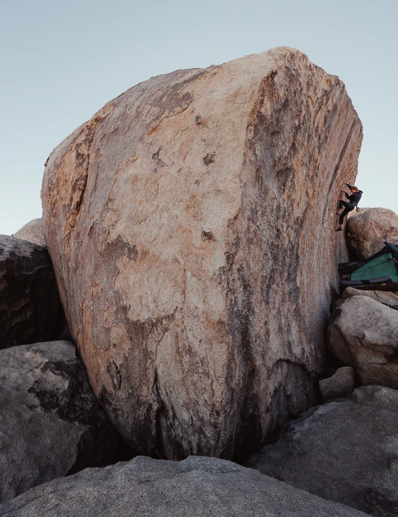